# EQ_Tsunami_Analysis

Beyza Özen

12/20/2021

Data source: https://www.kaggle.com/kanncaa1/earthquake-animation-with-plotly/notebook

```r
library(readr)
earthquake <- read_csv("data/earthquake.csv")
library(dplyr)
glimpse(earthquake)
```

```
## Rows: 23,412
## Columns: 21
## $ Date                         <chr> "01/02/1965", "01/04/1965", "01/05/1965",…
## $ Time                         <time> 13:44:18, 11:29:49, 18:05:58, 18:49:43, …
## $ Latitude                     <dbl> 19.246, 1.863, -20.579, -59.076, 11.938, …
## $ Longitude                    <dbl> 145.616, 127.352, -173.972, -23.557, 126.…
## $ Type                         <chr> "Earthquake", "Earthquake", "Earthquake",…
## $ Depth                        <dbl> 131.6, 80.0, 20.0, 15.0, 15.0, 35.0, 20.0…
## $ `Depth Error`                <dbl> NA, NA, NA, NA, NA, NA, NA, NA, NA, NA, N…
## $ `Depth Seismic Stations`     <dbl> NA, NA, NA, NA, NA, NA, NA, NA, NA, NA, N…
## $ Magnitude                    <dbl> 6.0, 5.8, 6.2, 5.8, 5.8, 6.7, 5.9, 6.0, 6…
## $ `Magnitude Type`             <chr> "MW", "MW", "MW", "MW", "MW", "MW", "MW",…
## $ `Magnitude Error`            <dbl> NA, NA, NA, NA, NA, NA, NA, NA, NA, NA, N…
## $ `Magnitude Seismic Stations` <dbl> NA, NA, NA, NA, NA, NA, NA, NA, NA, NA, N…
## $ `Azimuthal Gap`              <dbl> NA, NA, NA, NA, NA, NA, NA, NA, NA, NA, N…
## $ `Horizontal Distance`        <dbl> NA, NA, NA, NA, NA, NA, NA, NA, NA, NA, N…
## $ `Horizontal Error`           <dbl> NA, NA, NA, NA, NA, NA, NA, NA, NA, NA, N…
## $ `Root Mean Square`           <dbl> NA, NA, NA, NA, NA, NA, NA, NA, NA, NA, N…
## $ ID                           <chr> "ISCGEM860706", "ISCGEM860737", "ISCGEM86…
## $ Source                       <chr> "ISCGEM", "ISCGEM", "ISCGEM", "ISCGEM", "…
## $ `Location Source`            <chr> "ISCGEM", "ISCGEM", "ISCGEM", "ISCGEM", "…
## $ `Magnitude Source`           <chr> "ISCGEM", "ISCGEM", "ISCGEM", "ISCGEM", "…
## $ Status                       <chr> "Automatic", "Automatic", "Automatic", "A…
```

```r
library(lubridate)
earthquake$Date <- dmy(earthquake$Date)
```

# Why we have different magnitude types?

When we calculating the magnitude of an earthquake, we need to scale down all the effects of an earthquake into one number which is less than 10. It is an extremely complex process since which property should we use? The energy of released by the explosion? Should we consider the depth of occurrence? Are the length and width of the cracking plate important?

```r
earthquake %>% count(`Magnitude Type`) %>% distinct()
```

```
## # A tibble: 11 × 2
##    `Magnitude Type`     n
##    <chr>            <int>
##  1 MB                3761
##  2 MD                   6
##  3 MH                   5
##  4 ML                  77
##  5 MS                1702
##  6 MW                7722
##  7 MWB               2458
##  8 MWC               5669
##  9 MWR                 26
## 10 MWW               1983
## 11 <NA>                 3
```

```r
earthquake %>% count(`Magnitude Source`) %>% arrange(desc(n)) %>% slice(1:4)
```

```
## # A tibble: 4 × 2
##   `Magnitude Source`     n
##   <chr>              <int>
## 1 US                 10458
## 2 HRV                 8223
## 3 ISCGEM              2580
## 4 GCMT                1489
```

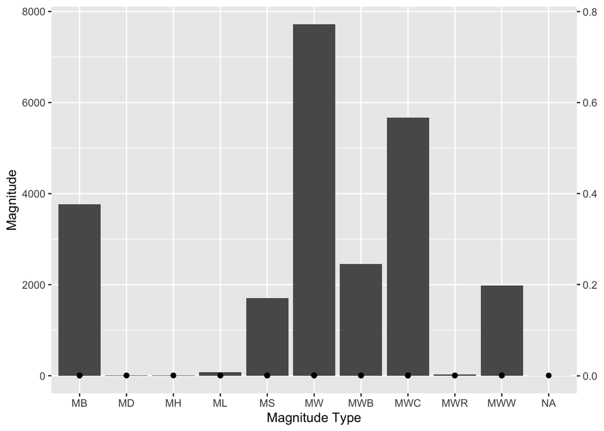

```r
library(ggplot2)


p <- ggplot(earthquake, aes(x = `Magnitude Type`))+
  geom_bar()+
  geom_point(aes(y = Magnitude))+
  scale_y_continuous(sec.axis = sec_axis(~.*0.0001))

p
```